# NLP Milestone Report

Zain Tejani

Sunday, March 29, 2015

### Introduction

The objective of the Capstone project is to develop a Natural Language Processing (NLP) prediction algorithm, to predict the next word in a sequence of words being typed. The primary data used in this project was collected from blog posts, news updates, and twitter feeds. Though data was provided in several languages, only the US English dataset is considered. The following report documents the import, partition, sampling, cleaning, processing, and analysis of trends seen in the data.

```r
library(tm);library(openNLP);library(RWeka);library(tau);library(ggplot2);library(stringi);library(SnowballC)
```

### Reading the data into R

The raw data was presented as a series of text files. These were imported into R using the following commands:

```r
blogs<-readLines("./final/en_US/en_US.blogs.txt")
tweets<-readLines("./final/en_US/en_US.twitter.txt")
news<-readLines("./final/en_US/en_US.news.txt")
```

Some basic exploratory analysis was performed, to get a better idea of the size and structure of the data.

```r
entries<-cbind(rbind(length(blogs),length(tweets),length(news)),rbind(sum(stri_count_words(blogs)),sum(stri_count_words(tweets)),sum(stri_count_words(news))))
a<-entries[,2]/entries[,1];entries<-cbind(entries,a)
rownames(entries)<-c("Blogs","Tweets","News");colnames(entries)<-c("Entries","Word Count","Words per Entry")
print(entries)
```

```
##        Entries Word Count Words per Entry
## Blogs   899288   38154238        42.42716
## Tweets 2360148   30218125        12.80349
## News     77259    2693898        34.86840
```

### Partition, Sampling, and Corpus Creation

Following this, the data was divided into training and test sets, in order to ensure the integrity of the testing set. Further analysis of the data is carried out only on the training set. These newly created datasets were saved to testing and training sub-directories. A 10% sample was taken from the training set, to build the initial Corpus.

```r
## Separating data into test and training sets
set.seed(28391)
blogBin<-rbinom(length(blogs), 1, 0.6)
tweetBin<-rbinom(length(tweets), 1, 0.6)
newsBin<-rbinom(length(news), 1, 0.6)

blogTrain<-blogs[blogBin==1];blogTest<-blogs[blogBin==0]
tweeTrain<-tweets[tweetBin==1];tweeTest<-tweets[tweetBin==0]
newsTrain<-news[newsBin==1];newsTest<-news[newsBin==0]

## Sampling from the training sets
blogS<-sample(blogTrain, round(length(blogTrain)*0.1))
tweetS<-sample(tweeTrain, round(length(tweeTrain)*0.1))
newS<-sample(newsTrain, round(length(newsTrain)*0.1))

## Removing unused data from the environment
rm(list=c("blogTrain","tweeTrain","newsTrain","blogs","tweets","news","blogBin","tweetBin","newsBin"))

## Creating the Corpus
sample1<-c(blogS,tweetS,newS)
rm(list=c("blogS","tweetS","newS"))
Corp1<-VCorpus(DirSource("./Train/Sample"))
```

### Data Cleaning

Once the Corpus is created, the data must be cleaned before it can be processed. This involves standardizing or normalizing several features that are part of the text. This includes uppercase lettering, punctuation, numbers, stop words, and unnecessary white space. Additionally, a profanity filter was also applied, using the list of words found [here](https://gist.github.com/ryanlewis/a37739d710ccdb4b406d). The Corpus was then stemmed, to reduce varying word forms to common roots.

```r
## Making all characters lower case
Corp1<-tm_map(Corp1, content_transformer(tolower))

## Apostrophe recognition
aPos<-content_transformer(function(x) gsub("â€™|â€œ|â€", "'", x));Corp1<-tm_map(Corp1, aPos)

## Profanity filter
BLEEP<-readLines("./profanity.txt");Corp1<-tm_map(Corp1, removeWords, BLEEP)
Corp1<-tm_map(Corp1, removeNumbers)
OneGram<-tm_map(Corp1, removeWords,stopwords("english"))
Corp1<-tm_map(Corp1, removePunctuation);OneGram<-tm_map(OneGram, removePunctuation)
Corp1<-tm_map(Corp1, stripWhitespace);OneGram<-tm_map(OneGram, stripWhitespace)

Corp1<-tm_map(Corp1, stemDocument);OneGram<-tm_map(OneGram, stemDocument)
```

```r
## Tokenizer functions for the TermDocumentMatrix() function for 1, 2, and 3-Gram models
OneToke<-function(x) NGramTokenizer(x, Weka_control(min = 1, max = 1))
TwoToke<-function(x) NGramTokenizer(x, Weka_control(min = 2, max = 2))
ThreeToke<-function(x) NGramTokenizer(x, Weka_control(min = 3, max = 3))

## Arranging the results into a dataframe
dtm1<-TermDocumentMatrix(OneGram,control=list(tokenize=OneToke))
dm1<-as.matrix(dtm1);v<-as.numeric(dm1);token<-rownames(dm1);df1<-as.data.frame(cbind(token,v))

dtm2<-TermDocumentMatrix(Corp1,control=list(tokenize=TwoToke))
dm2<-as.matrix(dtm2);v<-as.numeric(dm2);token<-rownames(dm2);df2<-as.data.frame(cbind(token,v))

dtm3<-TermDocumentMatrix(Corp1,control=list(tokenize=ThreeToke))
dm3<-as.matrix(dtm3);v<-as.numeric(dm3);token<-rownames(dm3);df3<-as.data.frame(cbind(token,v))

df1$v<-as.numeric(as.character(df1$v))
df2$v<-as.numeric(as.character(df2$v))
df3$v<-as.numeric(as.character(df3$v))

## Sorting to show the most frequently used tokens first
df1<-df1[order(df1[[2]],decreasing=TRUE),]
df2<-df2[order(df2[[2]],decreasing=TRUE),]
df3<-df3[order(df3[[2]],decreasing=TRUE),]
```

### Results

Here are some plots to provide insight into the structure of the data, and the prediction implications that can be drawn from them. Stop words were purposely included for the 2 and 3-Gram models, as they are often used in predictable situations and can be used to the advantage of the algorithm.

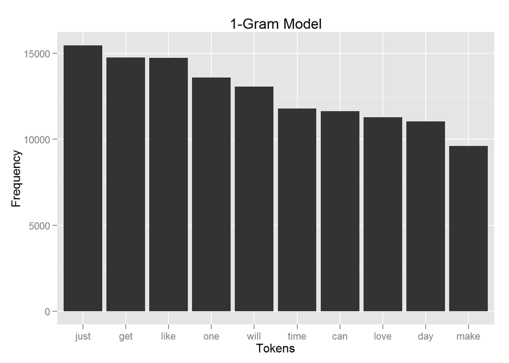

```r
qplot(reorder(token, -v), v, data=df1[1:10,], geom="histogram", stat="identity", main="1-Gram Model",xlab="Tokens",ylab="Frequency")
```

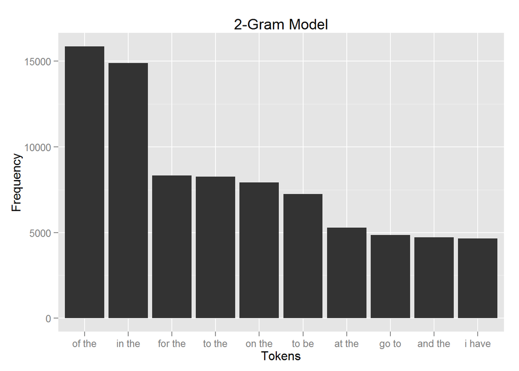

```r
qplot(reorder(token, -v), v, data=df2[1:10,], geom="histogram", stat="identity", main="2-Gram Model",xlab="Tokens",ylab="Frequency")
```

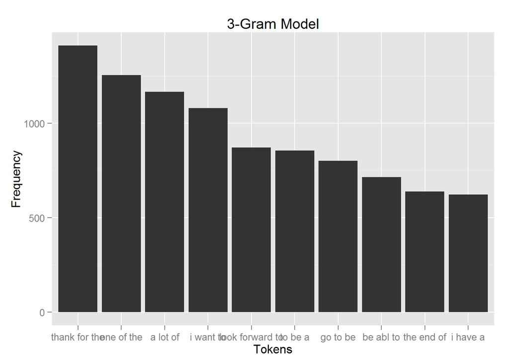

```r
qplot(reorder(token, -v), v, data=df3[1:10,], geom="histogram", stat="identity", main="3-Gram Model",xlab="Tokens",ylab="Frequency")
```